# Investor KPI Report – Telecom Customer Churn

# Roadmap: Churn Strategy Execution Plan

```r
# Define the strategic roadmap as a data frame
roadmap <- data.frame(
  Quarter = c("Q3", "Q3", "Q4", "Q4"),
  Initiative = c(
    "Automated outreach to high-risk churners (0–3 months)",
    "Launch fiber onboarding improvement pilot",
    "Contract incentive program for month-to-month users",
    "Churn dashboard for exec weekly reporting"
  ),
  Owner = c("Growth Team", "CX Ops", "Marketing", "Data Team"),
  Expected.KPI.Impact = c(
    "Churn -5%",
    "CSAT +10 pts",
    "Churn -3%",
    "Time-to-decision -25%"
  )
)
```

```r
roadmap <- roadmap
kbl(roadmap, caption = "Q3–Q4 Strategic Roadmap") %>%
  kable_styling(full_width = F)
```

Q3–Q4 Strategic Roadmap

| Quarter | Initiative | Owner | Expected.KPI.Impact |
| --- | --- | --- | --- |
| Q3 | Automated outreach to high-risk churners (0–3 months) | Growth Team | Churn -5% |
| Q3 | Launch fiber onboarding improvement pilot | CX Ops | CSAT +10 pts |
| Q4 | Contract incentive program for month-to-month users | Marketing | Churn -3% |
| Q4 | Churn dashboard for exec weekly reporting | Data Team | Time-to-decision -25% |

# Modeling

## Strategic Insights

- Customer complaints are the #1 actionable signal: Prioritize CX improvement and response time.
- Low engagement (frequency of use) is a churn risk: Consider auto-nudges or retention offers for inactive users.
- High-value churners are worth segmenting for personalized win-back campaigns.

```r
glm_full <- glm(Churn ~ ., data = churn_data, family = "binomial")

summary(glm_full)
```

```
##
## Call:
## glm(formula = Churn ~ ., family = "binomial", data = churn_data)
##
## Deviance Residuals:
##      Min        1Q    Median        3Q       Max
## -2.59049  -0.33912  -0.13595  -0.03192   2.92523
##
## Coefficients:
##                           Estimate Std. Error z value Pr(>|z|)
## (Intercept)             -2.6579070  0.8039318  -3.306 0.000946 ***
## Call..Failure            0.1314874  0.0178009   7.387 1.51e-13 ***
## Complains                4.0421354  0.2820449  14.332  < 2e-16 ***
## Subscription..Length    -0.0298973  0.0095140  -3.142 0.001675 **
## Charge..Amount          -0.4146409  0.1206564  -3.437 0.000589 ***
## Seconds.of.Use           0.0001086  0.0001442   0.753 0.451339
## Frequency.of.use        -0.0552806  0.0084907  -6.511 7.48e-11 ***
## Frequency.of.SMS        -0.0471298  0.0124199  -3.795 0.000148 ***
## Distinct.Called.Numbers -0.0110415  0.0096158  -1.148 0.250856
## Age.Group                0.0855448  0.2854640   0.300 0.764430
## Tariff.Plan              0.2302320  0.6335469   0.363 0.716305
## Status                   1.4100001  0.2010490   7.013 2.33e-12 ***
## Age                      0.0039169  0.0302350   0.130 0.896922
## Customer.Value           0.0082754  0.0028714   2.882 0.003951 **
## ---
## Signif. codes:  0 '***' 0.001 '**' 0.01 '*' 0.05 '.' 0.1 ' ' 1
##
## (Dispersion parameter for binomial family taken to be 1)
##
##     Null deviance: 2739.9  on 3149  degrees of freedom
## Residual deviance: 1385.1  on 3136  degrees of freedom
## AIC: 1413.1
##
## Number of Fisher Scoring iterations: 8
```

```r
glm_step <- stepAIC(glm_full, direction = "both")
```

```
## Start:  AIC=1413.11
## Churn ~ Call..Failure + Complains + Subscription..Length + Charge..Amount +
##     Seconds.of.Use + Frequency.of.use + Frequency.of.SMS + Distinct.Called.Numbers +
##     Age.Group + Tariff.Plan + Status + Age + Customer.Value
##
##                           Df Deviance    AIC
## - Age                      1   1385.1 1411.1
## - Age.Group                1   1385.2 1411.2
## - Tariff.Plan              1   1385.2 1411.2
## - Seconds.of.Use           1   1385.7 1411.7
## - Distinct.Called.Numbers  1   1386.5 1412.5
## <none>                         1385.1 1413.1
## - Customer.Value           1   1393.7 1419.7
## - Subscription..Length     1   1394.9 1420.9
## - Charge..Amount           1   1397.7 1423.7
## - Frequency.of.SMS         1   1400.4 1426.4
## - Frequency.of.use         1   1428.8 1454.8
## - Status                   1   1436.7 1462.7
## - Call..Failure            1   1443.9 1469.9
## - Complains                1   1739.8 1765.8
##
## Step:  AIC=1411.13
## Churn ~ Call..Failure + Complains + Subscription..Length + Charge..Amount +
##     Seconds.of.Use + Frequency.of.use + Frequency.of.SMS + Distinct.Called.Numbers +
##     Age.Group + Tariff.Plan + Status + Customer.Value
##
##                           Df Deviance    AIC
## - Tariff.Plan              1   1385.3 1409.3
## - Seconds.of.Use           1   1385.7 1409.7
## - Age.Group                1   1386.3 1410.3
## - Distinct.Called.Numbers  1   1386.5 1410.5
## <none>                         1385.1 1411.1
## + Age                      1   1385.1 1413.1
## - Customer.Value           1   1394.1 1418.1
## - Subscription..Length     1   1394.9 1418.9
## - Charge..Amount           1   1397.8 1421.8
## - Frequency.of.SMS         1   1401.2 1425.2
## - Frequency.of.use         1   1429.0 1453.0
## - Status                   1   1436.8 1460.8
## - Call..Failure            1   1444.0 1468.0
```

[output cut: 49 more lines]

```
##                           Df Deviance    AIC
## <none>                         1387.1 1407.1
## + Distinct.Called.Numbers  1   1385.8 1407.8
## - Age.Group                1   1389.9 1407.9
## + Seconds.of.Use           1   1386.7 1408.7
## + Tariff.Plan              1   1387.0 1409.0
## + Age                      1   1387.0 1409.0
## - Subscription..Length     1   1397.8 1415.8
## - Charge..Amount           1   1405.4 1423.4
## - Customer.Value           1   1411.3 1429.3
## - Frequency.of.SMS         1   1425.4 1443.4
## - Status                   1   1444.6 1462.6
## - Call..Failure            1   1448.1 1466.1
## - Frequency.of.use         1   1473.4 1491.4
## - Complains                1   1742.8 1760.8
```

> The final model confirms that churn is driven most strongly by customer complaints, call failures, and low product engagement (frequency of use/SMS). Interestingly, high-value and high-status customers are still at risk, suggesting retention should not be limited to low spenders. These findings can be directly used to build a churn scoring model or prioritize win-back outreach.

```r
summary(glm_step)
```

```
##
## Call:
## glm(formula = Churn ~ Call..Failure + Complains + Subscription..Length +
##     Charge..Amount + Frequency.of.use + Frequency.of.SMS + Age.Group +
##     Status + Customer.Value, family = "binomial", data = churn_data)
##
## Deviance Residuals:
##      Min        1Q    Median        3Q       Max
## -2.58573  -0.35040  -0.13188  -0.02862   2.94871
##
## Coefficients:
##                       Estimate Std. Error z value Pr(>|z|)
## (Intercept)          -2.595655   0.461143  -5.629 1.82e-08 ***
## Call..Failure         0.127658   0.016980   7.518 5.55e-14 ***
## Complains             4.056231   0.283306  14.317  < 2e-16 ***
## Subscription..Length -0.031012   0.009429  -3.289 0.001005 **
## Charge..Amount       -0.366569   0.097465  -3.761 0.000169 ***
## Frequency.of.use     -0.056215   0.006819  -8.244  < 2e-16 ***
## Frequency.of.SMS     -0.054616   0.008982  -6.081 1.20e-09 ***
## Age.Group             0.163305   0.097789   1.670 0.094924 .
## Status                1.458708   0.197347   7.392 1.45e-13 ***
## Customer.Value        0.010051   0.002033   4.943 7.69e-07 ***
## ---
## Signif. codes:  0 '***' 0.001 '**' 0.01 '*' 0.05 '.' 0.1 ' ' 1
##
## (Dispersion parameter for binomial family taken to be 1)
##
##     Null deviance: 2739.9  on 3149  degrees of freedom
## Residual deviance: 1387.1  on 3140  degrees of freedom
## AIC: 1407.1
##
## Number of Fisher Scoring iterations: 8
```

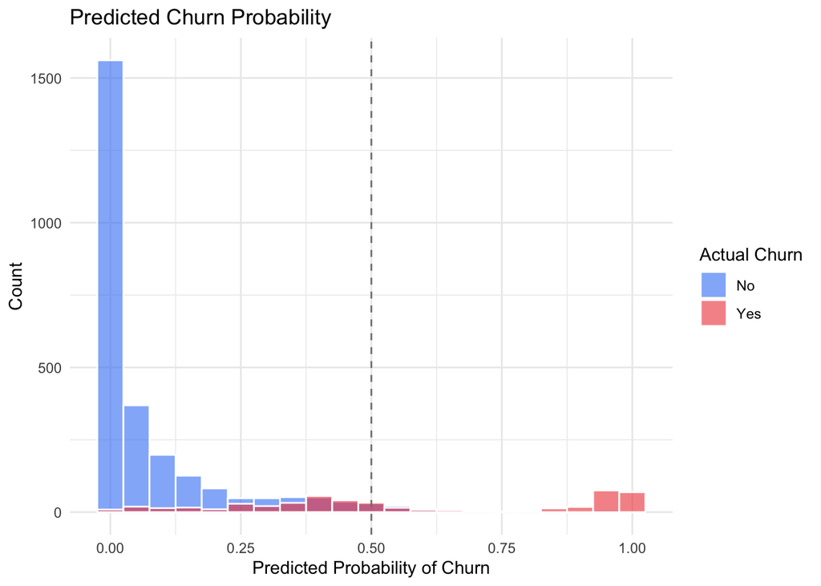

```r
# Predicted Churn Probability Plot
churn_data$predicted_prob <- predict(glm_step, type = "response")

# Histogram of predicted probabilities
ggplot(churn_data, aes(x = predicted_prob, fill = factor(Churn))) +
  geom_histogram(binwidth = 0.05, position = "identity", alpha = 0.6, color = "white") +
  scale_fill_manual(values = c("#3B82F6", "#EF4444"), labels = c("No", "Yes"), name = "Actual Churn") +
  geom_vline(xintercept = 0.5, linetype = "dashed", color = "grey50") +
  labs(
    title = "Predicted Churn Probability",
    x = "Predicted Probability of Churn",
    y = "Count"
  ) +
  theme_minimal()
```

```r
# Convert predicted probabilities to binary labels using 0.5 threshold
churn_data$predicted_class <- ifelse(churn_data$predicted_prob >= 0.5, 1, 0)

# Confusion matrix
conf_matrix <- confusionMatrix(
  factor(churn_data$predicted_class),
  factor(churn_data$Churn),
  positive = "1"
)
print(conf_matrix)
```

```
## Confusion Matrix and Statistics
##
##           Reference
## Prediction    0    1
##          0 2586  265
##          1   69  230
##
##                Accuracy : 0.894
##                  95% CI : (0.8827, 0.9045)
##     No Information Rate : 0.8429
##     P-Value [Acc > NIR] : < 2.2e-16
##
##                   Kappa : 0.5229
##
##  Mcnemar's Test P-Value : < 2.2e-16
##
##             Sensitivity : 0.46465
##             Specificity : 0.97401
##          Pos Pred Value : 0.76923
##          Neg Pred Value : 0.90705
##              Prevalence : 0.15714
##          Detection Rate : 0.07302
##    Detection Prevalence : 0.09492
##       Balanced Accuracy : 0.71933
##
##        'Positive' Class : 1
##
```

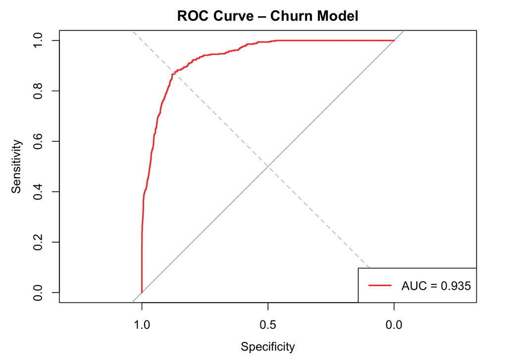

```r
# AUC and ROC curve
roc_curve <- roc(churn_data$Churn, churn_data$predicted_prob)

plot(roc_curve, col = "#EF4444", lwd = 2,
     main = "ROC Curve – Churn Model")
abline(a = 0, b = 1, lty = 2, col = "grey")
auc_value <- auc(roc_curve)
legend("bottomright", legend = paste("AUC =", round(auc_value, 3)),
       col = "#EF4444", lwd = 2)
```

# Final Model Evaluation Summary

## Confusion Matrix Highlights:

- Metric Value Interpretation
- Accuracy 89.4% Excellent overall performance
- Sensitivity 46.5% Captures ~47% of actual churners (room to improve)
- Specificity 97.4% Excellent at recognizing non-churners
- Kappa 0.523 Moderate agreement beyond chance
- Balanced Accuracy 72% Good for slightly imbalanced churn detection

## Tradeoff Insight:

- High specificity + modest sensitivity suggests:
- The model is very good at avoiding false alarms, but may miss some at-risk customers unless threshold is adjusted (e.g. 0.3 instead of 0.5).

## ROC Curve:

- AUC = 0.935 → Strong classifier
- Excellent separation between churn and non-churn classes
- Model performs far better than random (AUC > 0.8 is considered strong)

## Business Recommendation:

- With ~90% accuracy and AUC of 0.935, the model is highly useful for:
  - Targeting users above 0.5 churn probability
  - Flagging segments for retention intervention
  - Monitoring changes in churn behavior over time